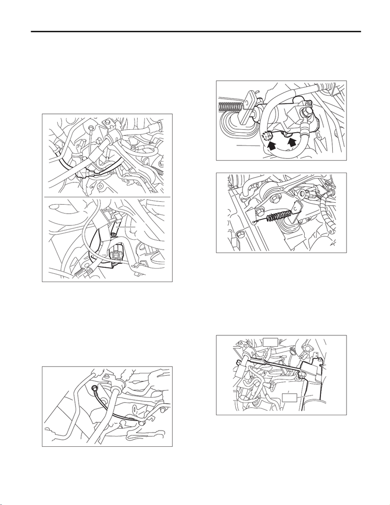

6MT(TY85)-31

Manual Transmission Assembly

MANUAL TRANSMISSION AND DIFFERENTIAL

6. Manual Transmission As-

sembly

A: REMOVAL

1) Disconnect the ground cable from battery.

2) Remove the intercooler. <Ref. to IN(STI)-13,

REMOVAL, Intercooler.>

3) Disconnect the following harness connectors,

and then remove the engine hanger rear.

4) Remove the secondary air combination valve.

<Ref. to EC(STI)-54, SECONDARY AIR COMBI-

NATION VALVE LH, REMOVAL, Secondary Air

Combination Valve.>

5) Disconnect the transmission radio ground cord

terminal.

6) Remove the starter assembly. <Ref. to SC(STI)-

7, REMOVAL, Starter.>

7) Remove the operating cylinder from the trans-

mission.

NOTE:

Hang the removed operating cylinder with a piece

of wire.

8) Remove the return spring from the release fork.

9) Remove the pitching stopper. <Ref. to

6MT(TY85)-29, PITCHING STOPPER, REMOV-

AL, Transmission Mounting System.>

10) Remove the pitching stopper bracket, return

spring bracket, and transmission radio ground ca-

ble.

11) Set the ST.

ST1 41099AA011 ENGINE SUPPORT BRACK-

ET

ST2 41099AA020 ENGINE SUPPORT

(A) Rear oxygen sensor connector

(B) Neutral position switch backup light switch con-

nector

MT-03088

(B)

(A)

MT-03086

CL-00445

MT-02302

MT-03091

ST2

ST1

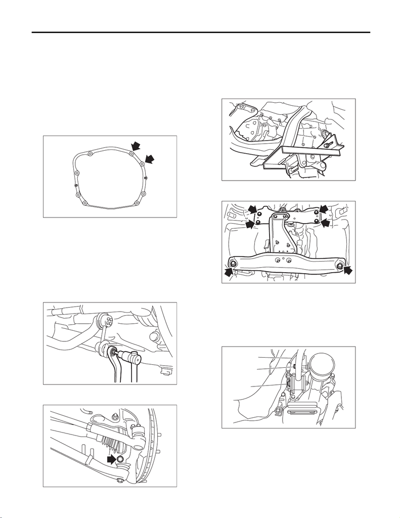

6MT(TY85)-32

Manual Transmission Assembly

MANUAL TRANSMISSION AND DIFFERENTIAL

12) Remove the clutch release shaft.

(1) Remove the plug using a hexagon wrench.

(2) Attach a 6 mm (0.24 in) bolt to the release

shaft, and pull out the release shaft.

(3) Lift the release fork, and remove from the

claw of the release bearing. Pull the release

fork to the engine side, and make it so that it

moves freely.

13) Remove the center exhaust pipe. <Ref. to

EX(STI)-7, REMOVAL, Center Exhaust Pipe.>

14) Remove the bolts which hold upper side of

transmission to engine.

15) Remove the front wheels.

16) Lift up the vehicle, and remove the transmis-

sion under cover.

17) Drain transmission gear oil completely. <Ref. to

6MT(TY85)-26, REPLACEMENT, Transmission

Gear Oil.>

18) Remove the heat shield cover.

19) Remove the propeller shaft. <Ref. to DS-12,

REMOVAL, Propeller Shaft.>

20) Remove the front stabilizer link.

21) Remove the ball joint of front arm from the

housing.

22) Remove the front drive shaft. <Ref. to DS-48,

REMOVAL, Front Drive Shaft.>

23) Place the transmission jack under the transmis-

sion.

CAUTION:

Always support the transmission case with a

transmission jack.

24) Remove the front crossmember and rear cross-

member from the vehicle.

25) Move the transmission to the right side of the

vehicle, and remove the joint COMPL, stay bolts

and reverse check cable.

NOTE:

If the transmission is not moved aside, the joint

COMPL and stay bolts may contact the body and

cause damage.

MT-01524

FS-00117

FS-00106

(A) Joint COMPL bolt

(B) Stay bolt

(C) Reverse check cable

MT-03193

MT-03194

MT-00886

(C)

(A)

(B)

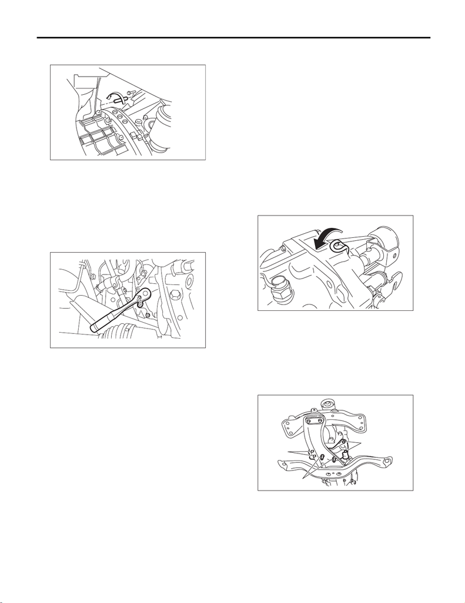

6MT(TY85)-33

Manual Transmission Assembly

MANUAL TRANSMISSION AND DIFFERENTIAL

26) Tighten the turnbuckle of the ST to tilt the en-

gine assembly towards the back.

27) Remove the bolts and nuts holding the bottom

of transmission to the engine, and remove the

transmission from the vehicle.

NOTE:

• During removal, be careful not to hit the trans-

mission against the body when pulling towards the

rear.

• The clutch pipe and breather pipe may interfere

with each other. Remove carefully.

28) Remove the transmission cushion rubber from

the transmission assembly.

B: INSTALLATION

1) Set the release fork, release bearing and release

shaft to the transmission. <Ref. to CL-17, INSTAL-

LATION, Release Bearing and Lever.>

2) Replace the front differential side retainer oil

seal. <Ref. to 6MT(TY85)-28, REPLACEMENT,

Differential Side Retainer Oil Seal.>

NOTE:

Be sure to replace the differential side oil seal after

the procedure of removing front drive shaft from

transmission.

3) Strike and bend the transmission hanger of

transmission rear with a rubber hammer etc. so that

it gets in contact with the transmission case.

CAUTION:

Do not apply extra overload or impact to the

transmission case.

4) Install the transmission cushion rubber to the

transmission, and tighten the bolt (A).

5) Install the transmission cushion rubber to the

center crossmember, and temporarily tighten the

nut (B).

Tightening torque:

Bolt (A)

35 N·m (3.6 kgf-m, 25.8 ft-lb)

6) Install the transmission onto the engine.

MT-00463

MT-03094

MT-02303

MT-03191

(A)

(A)

(B)

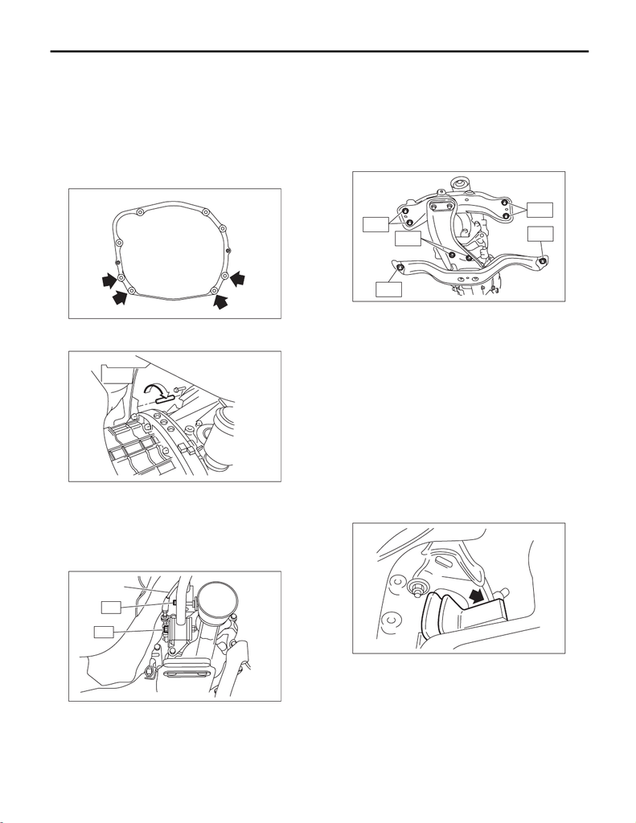

6MT(TY85)-34

Manual Transmission Assembly

MANUAL TRANSMISSION AND DIFFERENTIAL

7) Tighten the bolts and nuts which hold the lower

side of transmission to the engine.

NOTE:

• Make sure that the main shaft spline is complete-

ly inserted.

• Make sure that the rear end of the engine is set

low.

Tightening torque:

50 N·m (5.1 kgf-m, 36.9 ft-lb)

8) Loosen the turnbuckle of ST to return the engine

to its original position.

9) Move the transmission to the right side of the ve-

hicle, and attach the joint COMPL, stay bolts and

reverse check cable.

Tightening torque:

T1: 12 N·m (1.2 kgf-m, 8.9 ft-lb)

T2: 32 N·m (3.3 kgf-m, 23.6 ft-lb)

10) Tighten the mounting bolts for front crossmem-

ber and rear crossmember.

11) Tighten the transmission cushion rubber

mounting nut.

Tightening torque:

T1: 35 N·m (3.6 kgf-m, 25.8 ft-lb)

T2: 70 N·m (7.1 kgf-m, 51.6 ft-lb)

T3: 140 N·m (14.3 kgf-m, 103 ft-lb)

12) Lower the vehicle.

13) Install the starter. <Ref. to SC(STI)-7, INSTAL-

LATION, Starter.>

14) Tighten the bolts which hold the upper side of

the transmission to the engine.

Tightening torque:

50 N·m (5.1 kgf-m, 36.9 ft-lb)

15) Make sure that the release bearing is com-

pletely inserted.

NOTE:

• Push the release fork towards the operating cyl-

inder side until a clicking sound is heard. Pull the

release fork towards the engine side. If the release

fork is not in contact with the case, the setting is

complete.

• Confirm that the boot cover is set securely.

16) Install the pitching stopper bracket, return

spring bracket, and transmission radio ground ca-

ble.

Tightening torque:

41 N·m (4.2 kgf-m, 30.2 ft-lb)

(A) Reverse check cable

MT-00464

MT-01527

MT-00465

(A)

T2

T1

MT-03192

T2

T2

T3

T3

T1

MT-00467

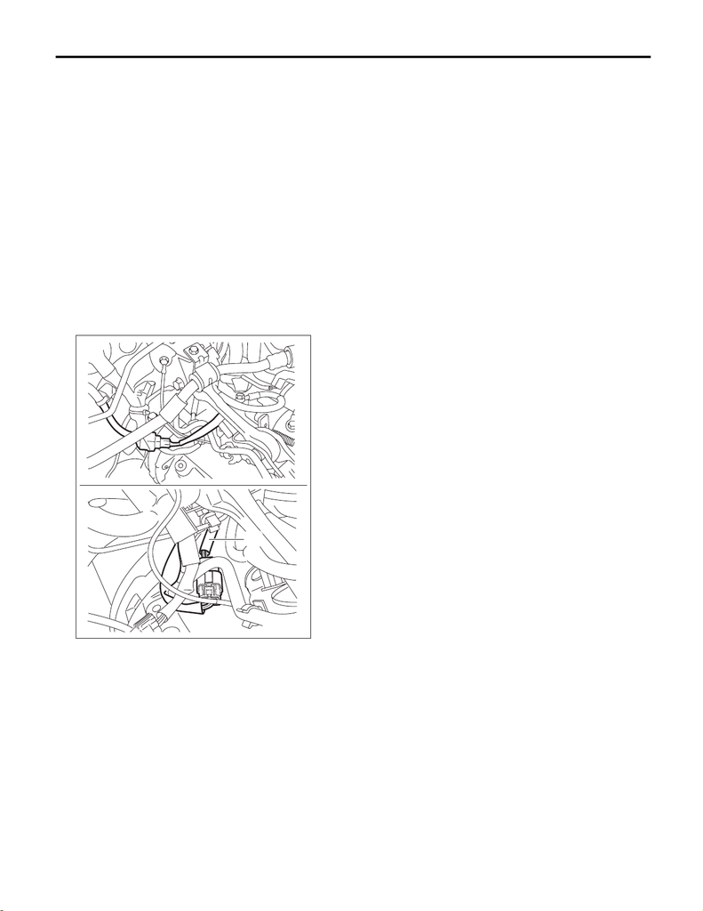

6MT(TY85)-35

Manual Transmission Assembly

MANUAL TRANSMISSION AND DIFFERENTIAL

17) Install the pitching stopper. <Ref. to

6MT(TY85)-29, INSTALLATION, Transmission

Mounting System.>

18) Install the return spring.

19) Install the clutch operating cylinder.

Tightening torque:

41 N·m (4.2 kgf-m, 30.2 ft-lb)

NOTE:

Check that the clutch hose is routed properly.

20) Install the starter assembly. <Ref. to SC(STI)-

7, INSTALLATION, Starter.>

21) Install the transmission radio ground terminal.

22) Install the secondary air combination valve.

<Ref. to EC(STI)-54, SECONDARY AIR COMBI-

NATION VALVE LH, INSTALLATION, Secondary

Air Combination Valve.>

23) Connect the following harness connectors,

then attach the engine hanger rear.

24) Lift up the vehicle.

25) Set the ST to side retainer.

ST 28399SA010 OIL SEAL PROTECTOR

26) Install the front drive shaft into the transmis-

sion.

NOTE:

Replace the circlip of drive shaft with a new part.

27) Install the front drive shaft into transmission, re-

move the ST and insert the drive shaft securely.

ST 28399SA010 OIL SEAL PROTECTOR

28) Install the ball joint of the front arm.

Tightening torque:

50 N·m (5.1 kgf-m, 36.9 ft-lb)

29) Install the front stabilizer link.

Tightening torque:

45 N·m (4.6 kgf-m, 33.2 ft-lb)

NOTE:

Use a new self-locking nut.

30) Install the propeller shaft. <Ref. to DS-14, IN-

STALLATION, Propeller Shaft.>

31) Install the heat shield cover.

Tightening torque:

18 N·m (1.8 kgf-m, 13.3 ft-lb)

32) Install the center exhaust pipe. <Ref. to

EX(STI)-8, INSTALLATION, Center Exhaust

Pipe.>

33) Fill the transmission gear oil. <Ref. to

6MT(TY85)-26, REPLACEMENT, Transmission

Gear Oil.>

34) Install the transmission under cover.

35) Install the intercooler. <Ref. to IN(STI)-14, IN-

STALLATION, Intercooler.>

36) Connect the battery ground terminal.

(A) Rear oxygen sensor connector

(B) Neutral position switch backup light switch con-

nector

MT-03088

(B)

(A)